# Risk Factor Analysis

## Outcome Variable

**Outcome Variable:** pers_wast

## Predictor Variables

**Intervention Variable:** perdiar6

**Adjustment Set:**

- arm
- sex
- W_mage
- meducyrs
- feducyrs
- hhwealth_quart
- hfoodsec
- W_mhtcm
- W_mwtkg
- W_mbmi
- W_birthwt
- W_birthlen
- W_nrooms
- month
- brthmon
- impfloor
- impsan
- safeh20
- delta_W_mage
- delta_meducyrs
- delta_feducyrs
- delta_hhwealth_quart
- delta_hfoodsec
- delta_W_mhtcm
- delta_W_mwtkg
- delta_W_mbmi
- delta_W_birthwt
- delta_W_birthlen
- delta_W_nrooms
- delta_month
- delta_brthmon
- delta_impfloor
- delta_impsan
- delta_safeh20

## Stratifying Variables

The analysis was stratified on these variable(s):

- agecat
- studyid
- country

## Data Summary

| agecat | studyid | country | perdiar6 | pers_wast | n_cell | n |
| --- | --- | --- | --- | --- | --- | --- |
| 0-24 months | CMIN | BANGLADESH | 0% | 0 | 82 | 257 |
| 0-24 months | CMIN | BANGLADESH | 0% | 1 | 5 | 257 |
| 0-24 months | CMIN | BANGLADESH | (0%, 5%] | 0 | 54 | 257 |
| 0-24 months | CMIN | BANGLADESH | (0%, 5%] | 1 | 6 | 257 |
| 0-24 months | CMIN | BANGLADESH | >5% | 0 | 101 | 257 |
| 0-24 months | CMIN | BANGLADESH | >5% | 1 | 9 | 257 |
| 0-24 months | CONTENT | PERU | 0% | 0 | 115 | 215 |
| 0-24 months | CONTENT | PERU | 0% | 1 | 0 | 215 |
| 0-24 months | CONTENT | PERU | (0%, 5%] | 0 | 43 | 215 |
| 0-24 months | CONTENT | PERU | (0%, 5%] | 1 | 0 | 215 |
| 0-24 months | CONTENT | PERU | >5% | 0 | 57 | 215 |
| 0-24 months | CONTENT | PERU | >5% | 1 | 0 | 215 |
| 0-24 months | EE | PAKISTAN | 0% | 0 | 308 | 377 |
| 0-24 months | EE | PAKISTAN | 0% | 1 | 32 | 377 |
| 0-24 months | EE | PAKISTAN | (0%, 5%] | 0 | 34 | 377 |
| 0-24 months | EE | PAKISTAN | (0%, 5%] | 1 | 1 | 377 |
| 0-24 months | EE | PAKISTAN | >5% | 0 | 2 | 377 |
| 0-24 months | EE | PAKISTAN | >5% | 1 | 0 | 377 |
| 0-24 months | MAL-ED | BANGLADESH | 0% | 0 | 69 | 248 |
| 0-24 months | MAL-ED | BANGLADESH | 0% | 1 | 4 | 248 |
| 0-24 months | MAL-ED | BANGLADESH | (0%, 5%] | 0 | 90 | 248 |
| 0-24 months | MAL-ED | BANGLADESH | (0%, 5%] | 1 | 6 | 248 |
| 0-24 months | MAL-ED | BANGLADESH | >5% | 0 | 76 | 248 |
| 0-24 months | MAL-ED | BANGLADESH | >5% | 1 | 3 | 248 |
| 0-24 months | MAL-ED | BRAZIL | 0% | 0 | 199 | 218 |
| 0-24 months | MAL-ED | BRAZIL | 0% | 1 | 2 | 218 |
| 0-24 months | MAL-ED | BRAZIL | (0%, 5%] | 0 | 15 | 218 |
| 0-24 months | MAL-ED | BRAZIL | (0%, 5%] | 1 | 0 | 218 |
| 0-24 months | MAL-ED | BRAZIL | >5% | 0 | 2 | 218 |
| 0-24 months | MAL-ED | BRAZIL | >5% | 1 | 0 | 218 |
| 0-24 months | MAL-ED | INDIA | 0% | 0 | 48 | 241 |
| 0-24 months | MAL-ED | INDIA | 0% | 1 | 4 | 241 |
| 0-24 months | MAL-ED | INDIA | (0%, 5%] | 0 | 118 | 241 |
| 0-24 months | MAL-ED | INDIA | (0%, 5%] | 1 | 11 | 241 |
| 0-24 months | MAL-ED | INDIA | >5% | 0 | 54 | 241 |
| 0-24 months | MAL-ED | INDIA | >5% | 1 | 6 | 241 |
| 0-24 months | MAL-ED | NEPAL | 0% | 0 | 78 | 238 |
| 0-24 months | MAL-ED | NEPAL | 0% | 1 | 3 | 238 |
| 0-24 months | MAL-ED | NEPAL | (0%, 5%] | 0 | 76 | 238 |
| 0-24 months | MAL-ED | NEPAL | (0%, 5%] | 1 | 1 | 238 |
| 0-24 months | MAL-ED | NEPAL | >5% | 0 | 80 | 238 |
| 0-24 months | MAL-ED | NEPAL | >5% | 1 | 0 | 238 |
| 0-24 months | MAL-ED | PERU | 0% | 0 | 71 | 284 |
| 0-24 months | MAL-ED | PERU | 0% | 1 | 1 | 284 |
| 0-24 months | MAL-ED | PERU | (0%, 5%] | 0 | 93 | 284 |
| 0-24 months | MAL-ED | PERU | (0%, 5%] | 1 | 0 | 284 |
| 0-24 months | MAL-ED | PERU | >5% | 0 | 119 | 284 |
| 0-24 months | MAL-ED | PERU | >5% | 1 | 0 | 284 |
| 0-24 months | MAL-ED | SOUTH AFRICA | 0% | 0 | 204 | 275 |
| 0-24 months | MAL-ED | SOUTH AFRICA | 0% | 1 | 2 | 275 |
| 0-24 months | MAL-ED | SOUTH AFRICA | (0%, 5%] | 0 | 59 | 275 |
| 0-24 months | MAL-ED | SOUTH AFRICA | (0%, 5%] | 1 | 0 | 275 |
| 0-24 months | MAL-ED | SOUTH AFRICA | >5% | 0 | 10 | 275 |
| 0-24 months | MAL-ED | SOUTH AFRICA | >5% | 1 | 0 | 275 |
| 0-24 months | MAL-ED | TANZANIA, UNITED REPUBLIC OF | 0% | 0 | 106 | 253 |
| 0-24 months | MAL-ED | TANZANIA, UNITED REPUBLIC OF | 0% | 1 | 0 | 253 |
| 0-24 months | MAL-ED | TANZANIA, UNITED REPUBLIC OF | (0%, 5%] | 0 | 101 | 253 |
| 0-24 months | MAL-ED | TANZANIA, UNITED REPUBLIC OF | (0%, 5%] | 1 | 0 | 253 |
| 0-24 months | MAL-ED | TANZANIA, UNITED REPUBLIC OF | >5% | 0 | 46 | 253 |
| 0-24 months | MAL-ED | TANZANIA, UNITED REPUBLIC OF | >5% | 1 | 0 | 253 |
| 0-24 months | NIH-Birth | BANGLADESH | 0% | 0 | 112 | 534 |
| 0-24 months | NIH-Birth | BANGLADESH | 0% | 1 | 12 | 534 |
| 0-24 months | NIH-Birth | BANGLADESH | (0%, 5%] | 0 | 155 | 534 |
| 0-24 months | NIH-Birth | BANGLADESH | (0%, 5%] | 1 | 12 | 534 |
| 0-24 months | NIH-Birth | BANGLADESH | >5% | 0 | 220 | 534 |
| 0-24 months | NIH-Birth | BANGLADESH | >5% | 1 | 23 | 534 |
| 0-24 months | NIH-Crypto | BANGLADESH | 0% | 0 | 334 | 730 |
| 0-24 months | NIH-Crypto | BANGLADESH | 0% | 1 | 11 | 730 |
| 0-24 months | NIH-Crypto | BANGLADESH | (0%, 5%] | 0 | 163 | 730 |
| 0-24 months | NIH-Crypto | BANGLADESH | (0%, 5%] | 1 | 7 | 730 |
| 0-24 months | NIH-Crypto | BANGLADESH | >5% | 0 | 207 | 730 |
| 0-24 months | NIH-Crypto | BANGLADESH | >5% | 1 | 8 | 730 |
| 0-24 months | PROVIDE | BANGLADESH | 0% | 0 | 167 | 641 |
| 0-24 months | PROVIDE | BANGLADESH | 0% | 1 | 4 | 641 |
| 0-24 months | PROVIDE | BANGLADESH | (0%, 5%] | 0 | 253 | 641 |
| 0-24 months | PROVIDE | BANGLADESH | (0%, 5%] | 1 | 5 | 641 |
| 0-24 months | PROVIDE | BANGLADESH | >5% | 0 | 206 | 641 |
| 0-24 months | PROVIDE | BANGLADESH | >5% | 1 | 6 | 641 |

The following strata were considered:

- agecat: 0-24 months, studyid: CMIN, country: BANGLADESH
- agecat: 0-24 months, studyid: CONTENT, country: PERU
- agecat: 0-24 months, studyid: EE, country: PAKISTAN
- agecat: 0-24 months, studyid: MAL-ED, country: BANGLADESH
- agecat: 0-24 months, studyid: MAL-ED, country: BRAZIL
- agecat: 0-24 months, studyid: MAL-ED, country: INDIA
- agecat: 0-24 months, studyid: MAL-ED, country: NEPAL
- agecat: 0-24 months, studyid: MAL-ED, country: PERU
- agecat: 0-24 months, studyid: MAL-ED, country: SOUTH AFRICA
- agecat: 0-24 months, studyid: MAL-ED, country: TANZANIA, UNITED REPUBLIC OF
- agecat: 0-24 months, studyid: NIH-Birth, country: BANGLADESH
- agecat: 0-24 months, studyid: NIH-Crypto, country: BANGLADESH
- agecat: 0-24 months, studyid: PROVIDE, country: BANGLADESH

### Dropped Strata

Some strata were dropped due to rare outcomes:

- agecat: 0-24 months, studyid: CONTENT, country: PERU
- agecat: 0-24 months, studyid: EE, country: PAKISTAN
- agecat: 0-24 months, studyid: MAL-ED, country: BANGLADESH
- agecat: 0-24 months, studyid: MAL-ED, country: BRAZIL
- agecat: 0-24 months, studyid: MAL-ED, country: INDIA
- agecat: 0-24 months, studyid: MAL-ED, country: NEPAL
- agecat: 0-24 months, studyid: MAL-ED, country: PERU
- agecat: 0-24 months, studyid: MAL-ED, country: SOUTH AFRICA
- agecat: 0-24 months, studyid: MAL-ED, country: TANZANIA, UNITED REPUBLIC OF
- agecat: 0-24 months, studyid: PROVIDE, country: BANGLADESH

## Methods Detail

We're interested in the causal parameters $E[Y_a]$ for all values of $a \in \mathcal{A}$. These parameters represent the mean outcome if, possibly contrary to fact, we intervened to set all units to have $A=a$. Under the randomization and positivity assumptions, these are identified by the statistical parameters $\psi_a=E_W[E_{Y|A,W}(Y|A=a,W)]$. In addition, we're interested in the mean of $Y$, $E[Y]$ under no intervention (the observed mean). We will estimate these parameters by using SuperLearner to fit the relevant likelihood factors -- $E_{Y|A,W}(Y|A=a,W)$ and $p(A=a|W)$, and then updating our likelihood fit using a joint TMLE.

For unadjusted analyses ($W=\{\}$), initial likelihoods were estimated using Lrnr_glm to estimate the simple $E(Y|A)$ and Lrnr_mean to estimate $p(A)$. For adjusted analyses, a small library containing Lrnr_glmnet, Lrnr_xgboost, and Lrnr_mean was used.

Having estimated these parameters, we will then use the delta method to estimate relative risks and attributable risks relative to a prespecified baseline level of $A$.

# Results Detail

## Results Plots

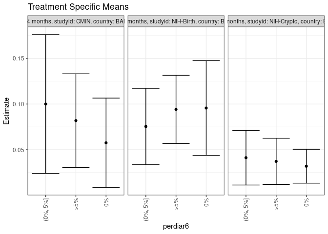

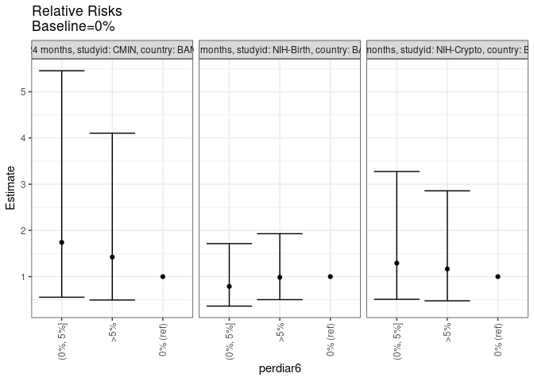

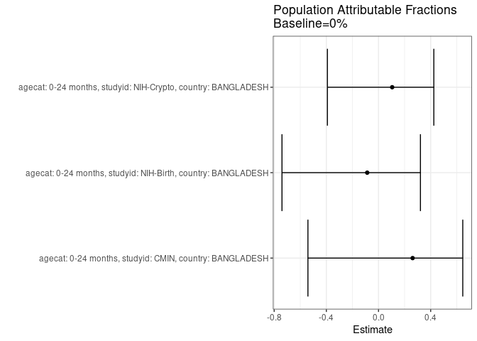

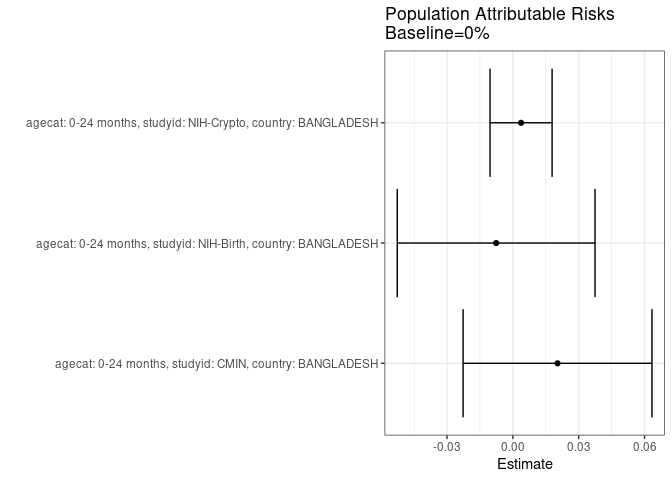

## Results Table

### Parameter: TSM

| agecat | studyid | country | intervention_level | baseline_level | estimate | ci_lower | ci_upper |
| --- | --- | --- | --- | --- | --- | --- | --- |
| 0-24 months | CMIN | BANGLADESH | 0% | NA | 0.0574713 | 0.0084700 | 0.1064726 |
| 0-24 months | CMIN | BANGLADESH | (0%, 5%] | NA | 0.1000000 | 0.0239428 | 0.1760572 |
| 0-24 months | CMIN | BANGLADESH | >5% | NA | 0.0818182 | 0.0304981 | 0.1331383 |
| 0-24 months | NIH-Birth | BANGLADESH | 0% | NA | 0.0956384 | 0.0437579 | 0.1475189 |
| 0-24 months | NIH-Birth | BANGLADESH | (0%, 5%] | NA | 0.0753977 | 0.0335318 | 0.1172636 |
| 0-24 months | NIH-Birth | BANGLADESH | >5% | NA | 0.0941526 | 0.0568397 | 0.1314654 |
| 0-24 months | NIH-Crypto | BANGLADESH | 0% | NA | 0.0318841 | 0.0133322 | 0.0504359 |
| 0-24 months | NIH-Crypto | BANGLADESH | (0%, 5%] | NA | 0.0411765 | 0.0112872 | 0.0710657 |
| 0-24 months | NIH-Crypto | BANGLADESH | >5% | NA | 0.0372093 | 0.0118920 | 0.0625267 |

### Parameter: E(Y)

| agecat | studyid | country | intervention_level | baseline_level | estimate | ci_lower | ci_upper |
| --- | --- | --- | --- | --- | --- | --- | --- |
| 0-24 months | CMIN | BANGLADESH | NA | NA | 0.0778210 | 0.0450051 | 0.1106369 |
| 0-24 months | NIH-Birth | BANGLADESH | NA | NA | 0.0880150 | 0.0639627 | 0.1120673 |
| 0-24 months | NIH-Crypto | BANGLADESH | NA | NA | 0.0356164 | 0.0221630 | 0.0490699 |

### Parameter: RR

| agecat | studyid | country | intervention_level | baseline_level | estimate | ci_lower | ci_upper |
| --- | --- | --- | --- | --- | --- | --- | --- |
| 0-24 months | CMIN | BANGLADESH | 0% | 0% | 1.0000000 | 1.0000000 | 1.000000 |
| 0-24 months | CMIN | BANGLADESH | (0%, 5%] | 0% | 1.7400000 | 0.5550642 | 5.454504 |
| 0-24 months | CMIN | BANGLADESH | >5% | 0% | 1.4236364 | 0.4939720 | 4.102946 |
| 0-24 months | NIH-Birth | BANGLADESH | 0% | 0% | 1.0000000 | 1.0000000 | 1.000000 |
| 0-24 months | NIH-Birth | BANGLADESH | (0%, 5%] | 0% | 0.7883622 | 0.3624947 | 1.714549 |
| 0-24 months | NIH-Birth | BANGLADESH | >5% | 0% | 0.9844639 | 0.5025619 | 1.928457 |
| 0-24 months | NIH-Crypto | BANGLADESH | 0% | 0% | 1.0000000 | 1.0000000 | 1.000000 |
| 0-24 months | NIH-Crypto | BANGLADESH | (0%, 5%] | 0% | 1.2914439 | 0.5093913 | 3.274157 |
| 0-24 months | NIH-Crypto | BANGLADESH | >5% | 0% | 1.1670190 | 0.4767258 | 2.856848 |

### Parameter: PAR

| agecat | studyid | country | intervention_level | baseline_level | estimate | ci_lower | ci_upper |
| --- | --- | --- | --- | --- | --- | --- | --- |
| 0-24 months | CMIN | BANGLADESH | 0% | NA | 0.0203497 | -0.0226891 | 0.0633886 |
| 0-24 months | NIH-Birth | BANGLADESH | 0% | NA | -0.0076234 | -0.0526903 | 0.0374435 |
| 0-24 months | NIH-Crypto | BANGLADESH | 0% | NA | 0.0037324 | -0.0104046 | 0.0178694 |

### Parameter: PAF

| agecat | studyid | country | intervention_level | baseline_level | estimate | ci_lower | ci_upper |
| --- | --- | --- | --- | --- | --- | --- | --- |
| 0-24 months | CMIN | BANGLADESH | 0% | NA | 0.2614943 | -0.5412670 | 0.6461413 |
| 0-24 months | NIH-Birth | BANGLADESH | 0% | NA | -0.0866151 | -0.7401445 | 0.3214745 |
| 0-24 months | NIH-Crypto | BANGLADESH | 0% | NA | 0.1047938 | -0.3918344 | 0.4242173 |